# Predict Future Sales

## * 대회 링크 : https://www.kaggle.com/c/competitive-data-science-predict-future-sales/

- 대회 목표 :

  > 러시아 최대 소프트웨어 회사 중 하나인 1C Company에서 제공하는 일일 판매 데이터(2013년 1월 ~ 2015년 10월)를 바탕으로, 2015년 11월 모든 shop(매장)의 item(제품) 총 판매량 예측.
- 대회 평가 지표 : root mean squared error (RMSE).

# [ 파일 설명 ]

- sales_train.csv : 훈련 세트. 2013년 1월부터 2015년 10월까지의 일일 기록 데이터.
- test.csv : 테스트 세트. 2015년 11월 shop과 item의 매출을 예측해야 함.
- sample_submission.csv : 제출 파일.
- items.csv : item에 대한 추가 정보.
- item_categories.csv : item 카테고리에 대한 추가 정보.
- shops.csv : shop에 대한 추가 정보.

# [ 데이터 설명 ]

- date : dd / mm / yyyy 형식의 날짜.
- date_block_num : 편의를 위해 사용되는 연속된 월 번호. ex) 2013년 1월은 0, 2013년 2월은 1, ... 2015년 10월은 33.
- shop_id : shop의 고유 식별자.
- item_id : item의 고유 식별자.
- item_price : item 가격.
- item_cnt_day : 판매된 item 개수.
- ID :테스트 세트 내에서 (shop, item) 튜플을 나타내는 ID.
- item_name : item 이름.
- shop_name : shop 이름.
- item_category_id : item 카테고리의 고유 식별자.
- item_category_name : item 카테고리 이름.

# [ 목차 ]

## 1. 데이터 불러오고 개략적으로 살펴보기

```
* 가. train, test, sub.
* 나. items, items_categories, shops.
```

## 2. 데이터 전처리

```
* 가. train.date 파생변수 생성.
* 나. items, items_categories, shops 라벨인코딩.
* 다. train과 items, items_categories, shops 통합.
* 라. test와 items, items_categories, shops 통합.
```

## 3. 시각화

```
* 가. matplotlib.
* 나. seaborn.
* 다. plotly.
```

## 4. 머신러닝

```
* 가. train_test_split.
* 나. 여러가지 머신러닝 모델.
    * ㄱ. k-최근접 이웃 - KNeighborsRegressor.
    * ㄴ. 선형모델 - LinearRegression, Lasso, Ridge.
    * ㄷ. 결정트리 - DecisionTreeRegressor.
    * ㄹ. 결정트리의 앙상블 - RandomForestRegressor, GradientBoostingRegressor.
```

## 5. 결론

```
* 가. 가장 성능이 좋은 모델 제출.
```

# 1. 데이터 불러오고 개략적으로 살펴보기

## 가. train, test, sub

```python
import pandas as pd

train = pd.read_csv("sales_train.csv")
test = pd.read_csv("test.csv")
sub = pd.read_csv("sample_submission.csv")
```

### ㄱ. 행렬 형태

```python
print(train.shape, test.shape, sub.shape, sep='\n\n')
```

```
(2935849, 6)

(214200, 3)

(214200, 2)
```

### ㄴ. 특성(특징)(Feature)

```python
print(train.columns, test.columns, sub.columns, sep='\n\n')
```

```
Index(['date', 'date_block_num', 'shop_id', 'item_id', 'item_price',
       'item_cnt_day'],
      dtype='object')

Index(['ID', 'shop_id', 'item_id'], dtype='object')

Index(['ID', 'item_cnt_month'], dtype='object')
```

### ㄷ. train

```python
train.head()
```

|  | date | date_block_num | shop_id | item_id | item_price | item_cnt_day |
| --- | --- | --- | --- | --- | --- | --- |
| 0 | 02.01.2013 | 0 | 59 | 22154 | 999.00 | 1.0 |
| 1 | 03.01.2013 | 0 | 25 | 2552 | 899.00 | 1.0 |
| 2 | 05.01.2013 | 0 | 25 | 2552 | 899.00 | -1.0 |
| 3 | 06.01.2013 | 0 | 25 | 2554 | 1709.05 | 1.0 |
| 4 | 15.01.2013 | 0 | 25 | 2555 | 1099.00 | 1.0 |

### ㄹ. test

```python
test.head()
```

|  | ID | shop_id | item_id |
| --- | --- | --- | --- |
| 0 | 0 | 5 | 5037 |
| 1 | 1 | 5 | 5320 |
| 2 | 2 | 5 | 5233 |
| 3 | 3 | 5 | 5232 |
| 4 | 4 | 5 | 5268 |

### ㅁ. sub

```python
sub.head()
```

|  | ID | item_cnt_month |
| --- | --- | --- |
| 0 | 0 | 0.5 |
| 1 | 1 | 0.5 |
| 2 | 2 | 0.5 |
| 3 | 3 | 0.5 |
| 4 | 4 | 0.5 |

### ㅂ. 자료형

```python
print(train.dtypes, test.dtypes, sub.dtypes, sep='\n\n')
```

```
date               object
date_block_num      int64
shop_id             int64
item_id             int64
item_price        float64
item_cnt_day      float64
dtype: object

ID         int64
shop_id    int64
item_id    int64
dtype: object

ID                  int64
item_cnt_month    float64
dtype: object
```

### ㅅ. 결측치

```python
print(train.isnull().sum(), test.isnull().sum(), sub.isnull().sum(), sep='\n\n')
```

```
date              0
date_block_num    0
shop_id           0
item_id           0
item_price        0
item_cnt_day      0
dtype: int64

ID         0
shop_id    0
item_id    0
dtype: int64

ID                0
item_cnt_month    0
dtype: int64
```

### ㅇ. 특성(특징)(Feature)별 중복되지 않는 data 개수

```python
train_columns = ['date', 'date_block_num', 'shop_id', 'item_id', 'item_price', 'item_cnt_day']
test_columns = ['ID', 'shop_id', 'item_id']
sub_columns = ['ID', 'item_cnt_month']

print("train")
for column1 in train_columns:
    print(f"{column1} :", len(train[column1].unique()), end='/ ')
print("\n")

print("test")
for column2 in test_columns:
    print(f"{column2} :", len(test[column2].unique()), end='/ ')
print("\n")

print("sub")
for column3 in sub_columns:
    print(f"{column3} :", len(sub[column3].unique()), end='/ ')
```

```
train
date : 1034/ date_block_num : 34/ shop_id : 60/ item_id : 21807/ item_price : 19993/ item_cnt_day : 198/

test
ID : 214200/ shop_id : 42/ item_id : 5100/

sub
ID : 214200/ item_cnt_month : 1/
```

### ㅈ. 요약

```python
train.describe() # 수치형 데이터 요약.
```

|  | date_block_num | shop_id | item_id | item_price | item_cnt_day |
| --- | --- | --- | --- | --- | --- |
| count | 2.935849e+06 | 2.935849e+06 | 2.935849e+06 | 2.935849e+06 | 2.935849e+06 |
| mean | 1.456991e+01 | 3.300173e+01 | 1.019723e+04 | 8.908532e+02 | 1.242641e+00 |
| std | 9.422988e+00 | 1.622697e+01 | 6.324297e+03 | 1.729800e+03 | 2.618834e+00 |
| min | 0.000000e+00 | 0.000000e+00 | 0.000000e+00 | -1.000000e+00 | -2.200000e+01 |
| 25% | 7.000000e+00 | 2.200000e+01 | 4.476000e+03 | 2.490000e+02 | 1.000000e+00 |
| 50% | 1.400000e+01 | 3.100000e+01 | 9.343000e+03 | 3.990000e+02 | 1.000000e+00 |
| 75% | 2.300000e+01 | 4.700000e+01 | 1.568400e+04 | 9.990000e+02 | 1.000000e+00 |
| max | 3.300000e+01 | 5.900000e+01 | 2.216900e+04 | 3.079800e+05 | 2.169000e+03 |

```python
train.describe(include='O')   # 범주형 데이터 요약.
```

|  | date |
| --- | --- |
| count | 2935849 |
| unique | 1034 |
| top | 28.12.2013 |
| freq | 9434 |

```python
test.describe()
```

|  | ID | shop_id | item_id |
| --- | --- | --- | --- |
| count | 214200.000000 | 214200.000000 | 214200.000000 |
| mean | 107099.500000 | 31.642857 | 11019.398627 |
| std | 61834.358168 | 17.561933 | 6252.644590 |
| min | 0.000000 | 2.000000 | 30.000000 |
| 25% | 53549.750000 | 16.000000 | 5381.500000 |
| 50% | 107099.500000 | 34.500000 | 11203.000000 |
| 75% | 160649.250000 | 47.000000 | 16071.500000 |
| max | 214199.000000 | 59.000000 | 22167.000000 |

```python
sub.describe()
```

|  | ID | item_cnt_month |
| --- | --- | --- |
| count | 214200.000000 | 214200.0 |
| mean | 107099.500000 | 0.5 |
| std | 61834.358168 | 0.0 |
| min | 0.000000 | 0.5 |
| 25% | 53549.750000 | 0.5 |
| 50% | 107099.500000 | 0.5 |
| 75% | 160649.250000 | 0.5 |
| max | 214199.000000 | 0.5 |

## 나. items, items_categories, shops

```python
items = pd.read_csv("items.csv")
items_categories = pd.read_csv("item_categories.csv")
shops = pd.read_csv("shops.csv")
```

### ㄱ. 행렬 형태

```python
print(items.shape, items_categories.shape, shops.shape, sep='\n\n')
```

```
(22170, 3)

(84, 2)

(60, 2)
```

### ㄴ. 특성(특징)(Feature)

```python
print(items.columns, items_categories.columns, shops.columns, sep='\n\n')
```

```
Index(['item_name', 'item_id', 'item_category_id'], dtype='object')

Index(['item_category_name', 'item_category_id'], dtype='object')

Index(['shop_name', 'shop_id'], dtype='object')
```

### ㄷ. items

```python
items.head()
```

|  | item_name | item_id | item_category_id |
| --- | --- | --- | --- |
| 0 | ! ВО ВЛАСТИ НАВАЖДЕНИЯ (ПЛАСТ.) D | 0 | 40 |
| 1 | !ABBYY FineReader 12 Professional Edition Full... | 1 | 76 |
| 2 | ***В ЛУЧАХ СЛАВЫ (UNV) D | 2 | 40 |
| 3 | ***ГОЛУБАЯ ВОЛНА (Univ) D | 3 | 40 |
| 4 | ***КОРОБКА (СТЕКЛО) D | 4 | 40 |

### ㄹ. items_categories

```python
items_categories.head()
```

|  | item_category_name | item_category_id |
| --- | --- | --- |
| 0 | PC - Гарнитуры/Наушники | 0 |
| 1 | Аксессуары - PS2 | 1 |
| 2 | Аксессуары - PS3 | 2 |
| 3 | Аксессуары - PS4 | 3 |
| 4 | Аксессуары - PSP | 4 |

### ㅁ. shops

```python
shops.head()
```

|  | shop_name | shop_id |
| --- | --- | --- |
| 0 | !Якутск Орджоникидзе, 56 фран | 0 |
| 1 | !Якутск ТЦ "Центральный" фран | 1 |
| 2 | Адыгея ТЦ "Мега" | 2 |
| 3 | Балашиха ТРК "Октябрь-Киномир" | 3 |
| 4 | Волжский ТЦ "Волга Молл" | 4 |

### ㅂ. 자료형

```python
print(items.dtypes, items_categories.dtypes, shops.dtypes, sep='\n\n')
```

```
item_name           object
item_id              int64
item_category_id     int64
dtype: object

item_category_name    object
item_category_id       int64
dtype: object

shop_name    object
shop_id       int64
dtype: object
```

### ㅅ. 결측치

```python
print(items.isnull().sum(), items_categories.isnull().sum(), shops.isnull().sum(), sep='\n\n')
```

```
item_name           0
item_id             0
item_category_id    0
dtype: int64

item_category_name    0
item_category_id      0
dtype: int64

shop_name    0
shop_id      0
dtype: int64
```

### ㅇ. 특성(특징)(Feature)별 중복되지 않는 data 개수

```python
items_columns = ['item_name', 'item_id', 'item_category_id']
items_categories_columns = ['item_category_name', 'item_category_id']
shops_columns = ['shop_name', 'shop_id']

print("items")
for column4 in items_columns:
    print(f"{column4} :", len(items[column4].unique()), end='/ ')
print("\n")

print("items_categories")
for column5 in items_categories_columns:
    print(f"{column5} :", len(items_categories[column5].unique()), end='/ ')
print("\n")

print("shops")
for column6 in shops_columns:
    print(f"{column6} :", len(shops[column6].unique()), end='/ ')
```

```
items
item_name : 22170/ item_id : 22170/ item_category_id : 84/

items_categories
item_category_name : 84/ item_category_id : 84/

shops
shop_name : 60/ shop_id : 60/
```

### ㅈ. 요약

```python
items.describe()
```

|  | item_id | item_category_id |
| --- | --- | --- |
| count | 22170.00000 | 22170.000000 |
| mean | 11084.50000 | 46.290753 |
| std | 6400.07207 | 15.941486 |
| min | 0.00000 | 0.000000 |
| 25% | 5542.25000 | 37.000000 |
| 50% | 11084.50000 | 40.000000 |
| 75% | 16626.75000 | 58.000000 |
| max | 22169.00000 | 83.000000 |

```python
items_categories.describe()
```

|  | item_category_id |
| --- | --- |
| count | 84.000000 |
| mean | 41.500000 |
| std | 24.392622 |
| min | 0.000000 |
| 25% | 20.750000 |
| 50% | 41.500000 |
| 75% | 62.250000 |
| max | 83.000000 |

```python
shops.describe()
```

|  | shop_id |
| --- | --- |
| count | 60.000000 |
| mean | 29.500000 |
| std | 17.464249 |
| min | 0.000000 |
| 25% | 14.750000 |
| 50% | 29.500000 |
| 75% | 44.250000 |
| max | 59.000000 |

# 2. 데이터 전처리

## 가. train.date 파생변수 생성.

### ㄱ. 문자열타입(object)을 datetime64타입으로 변환

```python
train.dtypes # 변환 전
```

```
date               object
date_block_num      int64
shop_id             int64
item_id             int64
item_price        float64
item_cnt_day      float64
dtype: object
```

```python
train['date'] = pd.to_datetime(train['date'], format='%d.%m.%Y') # pd.to_datetime
```

```python
train.dtypes # 변환 후
```

```
date              datetime64[ns]
date_block_num             int64
shop_id                    int64
item_id                    int64
item_price               float64
item_cnt_day             float64
dtype: object
```

### ㄴ. 'year', 'month' feature 추가

```python
train.head() # 추가 전
```

|  | date | date_block_num | shop_id | item_id | item_price | item_cnt_day |
| --- | --- | --- | --- | --- | --- | --- |
| 0 | 2013-01-02 | 0 | 59 | 22154 | 999.00 | 1.0 |
| 1 | 2013-01-03 | 0 | 25 | 2552 | 899.00 | 1.0 |
| 2 | 2013-01-05 | 0 | 25 | 2552 | 899.00 | -1.0 |
| 3 | 2013-01-06 | 0 | 25 | 2554 | 1709.05 | 1.0 |
| 4 | 2013-01-15 | 0 | 25 | 2555 | 1099.00 | 1.0 |

```python
train['year'] = train['date'].dt.year
train['month'] = train['date'].dt.month
```

```python
train.head() # 추가 후
```

|  | date | date_block_num | shop_id | item_id | item_price | item_cnt_day | year | month |
| --- | --- | --- | --- | --- | --- | --- | --- | --- |
| 0 | 2013-01-02 | 0 | 59 | 22154 | 999.00 | 1.0 | 2013 | 1 |
| 1 | 2013-01-03 | 0 | 25 | 2552 | 899.00 | 1.0 | 2013 | 1 |
| 2 | 2013-01-05 | 0 | 25 | 2552 | 899.00 | -1.0 | 2013 | 1 |
| 3 | 2013-01-06 | 0 | 25 | 2554 | 1709.05 | 1.0 | 2013 | 1 |
| 4 | 2013-01-15 | 0 | 25 | 2555 | 1099.00 | 1.0 | 2013 | 1 |

## 나. items, items_categories, shops 라벨인코딩.

### ㄱ. items

```python
from sklearn.preprocessing import LabelEncoder
```

```python
items.head() # 라벨인코딩 전
```

|  | item_name | item_id | item_category_id |
| --- | --- | --- | --- |
| 0 | ! ВО ВЛАСТИ НАВАЖДЕНИЯ (ПЛАСТ.) D | 0 | 40 |
| 1 | !ABBYY FineReader 12 Professional Edition Full... | 1 | 76 |
| 2 | ***В ЛУЧАХ СЛАВЫ (UNV) D | 2 | 40 |
| 3 | ***ГОЛУБАЯ ВОЛНА (Univ) D | 3 | 40 |
| 4 | ***КОРОБКА (СТЕКЛО) D | 4 | 40 |

```python
le = LabelEncoder()
le = le.fit_transform(items["item_name"])
items["lbl_item_name"] = le
```

```python
items.head() # 라벨인코딩 후
```

|  | item_name | item_id | item_category_id | lbl_item_name |
| --- | --- | --- | --- | --- |
| 0 | ! ВО ВЛАСТИ НАВАЖДЕНИЯ (ПЛАСТ.) D | 0 | 40 | 0 |
| 1 | !ABBYY FineReader 12 Professional Edition Full... | 1 | 76 | 1 |
| 2 | ***В ЛУЧАХ СЛАВЫ (UNV) D | 2 | 40 | 2 |
| 3 | ***ГОЛУБАЯ ВОЛНА (Univ) D | 3 | 40 | 3 |
| 4 | ***КОРОБКА (СТЕКЛО) D | 4 | 40 | 4 |

### ㄴ. items_categories

```python
items_categories.head() # 라벨인코딩 전
```

|  | item_category_name | item_category_id |
| --- | --- | --- |
| 0 | PC - Гарнитуры/Наушники | 0 |
| 1 | Аксессуары - PS2 | 1 |
| 2 | Аксессуары - PS3 | 2 |
| 3 | Аксессуары - PS4 | 3 |
| 4 | Аксессуары - PSP | 4 |

```python
le = LabelEncoder()
le = le.fit_transform(items_categories["item_category_name"])
items_categories["lbl_item_category_name"] = le
```

```python
items_categories.head() # 라벨인코딩 후
```

|  | item_category_name | item_category_id | lbl_item_category_name |
| --- | --- | --- | --- |
| 0 | PC - Гарнитуры/Наушники | 0 | 0 |
| 1 | Аксессуары - PS2 | 1 | 1 |
| 2 | Аксессуары - PS3 | 2 | 2 |
| 3 | Аксессуары - PS4 | 3 | 3 |
| 4 | Аксессуары - PSP | 4 | 4 |

### ㄷ. shops

```python
shops.head() # 라벨인코딩 전
```

|  | shop_name | shop_id |
| --- | --- | --- |
| 0 | !Якутск Орджоникидзе, 56 фран | 0 |
| 1 | !Якутск ТЦ "Центральный" фран | 1 |
| 2 | Адыгея ТЦ "Мега" | 2 |
| 3 | Балашиха ТРК "Октябрь-Киномир" | 3 |
| 4 | Волжский ТЦ "Волга Молл" | 4 |

```python
le = LabelEncoder()
le = le.fit_transform(shops["shop_name"])
shops["lbl_shop_name"] = le
```

```python
shops.head() # 라벨인코딩 후
```

|  | shop_name | shop_id | lbl_shop_name |
| --- | --- | --- | --- |
| 0 | !Якутск Орджоникидзе, 56 фран | 0 | 0 |
| 1 | !Якутск ТЦ "Центральный" фран | 1 | 1 |
| 2 | Адыгея ТЦ "Мега" | 2 | 2 |
| 3 | Балашиха ТРК "Октябрь-Киномир" | 3 | 3 |
| 4 | Волжский ТЦ "Волга Молл" | 4 | 4 |

## 다. train과 items, items_categories, shops 통합.

### ㄱ. 통합

```python
new_train = pd.merge(train, items, on='item_id', how='inner')
new_train = pd.merge(new_train, items_categories, on='item_category_id', how='inner')
new_train = pd.merge(new_train, shops, on='shop_id', how='inner')

new_train.head()
```

|  | date | date_block_num | shop_id | item_id | item_price | item_cnt_day | year | month | item_name | item_category_id | lbl_item_name | item_category_name | lbl_item_category_name | shop_name | lbl_shop_name |
| --- | --- | --- | --- | --- | --- | --- | --- | --- | --- | --- | --- | --- | --- | --- | --- |
| 0 | 2013-01-02 | 0 | 59 | 22154 | 999.0 | 1.0 | 2013 | 1 | ЯВЛЕНИЕ 2012 (BD) | 37 | 22154 | Кино - Blu-Ray | 37 | Ярославль ТЦ "Альтаир" | 59 |
| 1 | 2013-04-26 | 3 | 59 | 944 | 150.0 | 1.0 | 2013 | 4 | 2012 (BD) | 37 | 944 | Кино - Blu-Ray | 37 | Ярославль ТЦ "Альтаир" | 59 |
| 2 | 2013-06-26 | 5 | 59 | 944 | 199.5 | 1.0 | 2013 | 6 | 2012 (BD) | 37 | 944 | Кино - Blu-Ray | 37 | Ярославль ТЦ "Альтаир" | 59 |
| 3 | 2013-07-20 | 6 | 59 | 944 | 199.5 | 1.0 | 2013 | 7 | 2012 (BD) | 37 | 944 | Кино - Blu-Ray | 37 | Ярославль ТЦ "Альтаир" | 59 |
| 4 | 2013-09-14 | 8 | 59 | 944 | 299.0 | 2.0 | 2013 | 9 | 2012 (BD) | 37 | 944 | Кино - Blu-Ray | 37 | Ярославль ТЦ "Альтаир" | 59 |

- how = 'outer' : 중복 여부와 상관없이 모든 데이터 출력.
- how = 'inner' : 중복된 데이터의 행만 출력.

### ㄴ. 'year', 'month', 'shop_id', 'item_id' feature를 기준으로 정렬

```python
new_train = new_train.groupby( ['year', 'month', 'shop_id', 'item_id'] ).sum()

new_train.head()
```

| year | month | shop_id | item_id | date_block_num | item_price | item_cnt_day | item_category_id | lbl_item_name | lbl_item_category_name | lbl_shop_name |
| --- | --- | --- | --- | --- | --- | --- | --- | --- | --- | --- |
| 2013 | 1 | 0 | 32 | 0 | 884.0 | 6.0 | 160 | 128 | 160 | 0 |
|  |  |  | 33 | 0 | 1041.0 | 3.0 | 111 | 99 | 111 | 0 |
|  |  |  | 35 | 0 | 247.0 | 1.0 | 40 | 35 | 40 | 0 |
|  |  |  | 43 | 0 | 221.0 | 1.0 | 40 | 43 | 40 | 0 |
|  |  |  | 51 | 0 | 257.0 | 2.0 | 114 | 102 | 114 | 0 |

### ㄷ. 필요 없는 feature 제거

```python
new_train = new_train.drop(['date_block_num'], axis=1)
new_train.head()
```

| year | month | shop_id | item_id | item_price | item_cnt_day | item_category_id | lbl_item_name | lbl_item_category_name | lbl_shop_name |
| --- | --- | --- | --- | --- | --- | --- | --- | --- | --- |
| 2013 | 1 | 0 | 32 | 884.0 | 6.0 | 160 | 128 | 160 | 0 |
|  |  |  | 33 | 1041.0 | 3.0 | 111 | 99 | 111 | 0 |
|  |  |  | 35 | 247.0 | 1.0 | 40 | 35 | 40 | 0 |
|  |  |  | 43 | 221.0 | 1.0 | 40 | 43 | 40 | 0 |
|  |  |  | 51 | 257.0 | 2.0 | 114 | 102 | 114 | 0 |

### ㄹ. train, new_train 통합

```python
brand_new_train = pd.merge(left = train,
                           right = new_train,
                           how = 'left',                                 # new_train을 train에 통합.
                           on = ['year', 'month', 'shop_id', 'item_id'], # 4가지 feature를 기준으로.
                           sort=False)
brand_new_train.head()
```

|  | date | date_block_num | shop_id | item_id | item_price_x | item_cnt_day_x | year | month | item_price_y | item_cnt_day_y | item_category_id | lbl_item_name | lbl_item_category_name | lbl_shop_name |
| --- | --- | --- | --- | --- | --- | --- | --- | --- | --- | --- | --- | --- | --- | --- |
| 0 | 2013-01-02 | 0 | 59 | 22154 | 999.00 | 1.0 | 2013 | 1 | 999.00 | 1.0 | 37 | 22154 | 37 | 59 |
| 1 | 2013-01-03 | 0 | 25 | 2552 | 899.00 | 1.0 | 2013 | 1 | 1798.00 | 0.0 | 116 | 5104 | 116 | 50 |
| 2 | 2013-01-05 | 0 | 25 | 2552 | 899.00 | -1.0 | 2013 | 1 | 1798.00 | 0.0 | 116 | 5104 | 116 | 50 |
| 3 | 2013-01-06 | 0 | 25 | 2554 | 1709.05 | 1.0 | 2013 | 1 | 1709.05 | 1.0 | 58 | 2554 | 58 | 25 |
| 4 | 2013-01-15 | 0 | 25 | 2555 | 1099.00 | 1.0 | 2013 | 1 | 1099.00 | 1.0 | 56 | 2555 | 56 | 25 |

[feature 설명]

- brand_new_train.item_price_x = train.item_price = 일별 item 가격.
- brand_new_train.item_cnt_day_x = train.item_cnt_day = 일별 판매된 item 개수.
- brand_new_train.item_price_y = 월별 item 가격.
- brand_new_train.item_cnt_day_y = 월별 판매된 item 개수. 즉 target 값.

## 라. test와 items, items_categories, shops 통합.

### ㄱ. 통합

```python
new_test = pd.merge(test, items, on='item_id', how='inner')
new_test = pd.merge(new_test, items_categories, on='item_category_id', how='inner')
new_test = pd.merge(new_test, shops, on='shop_id', how='inner')

new_test.head()
```

|  | ID | shop_id | item_id | item_name | item_category_id | lbl_item_name | item_category_name | lbl_item_category_name | shop_name | lbl_shop_name |
| --- | --- | --- | --- | --- | --- | --- | --- | --- | --- | --- |
| 0 | 0 | 5 | 5037 | NHL 15 [PS3, русские субтитры] | 19 | 5037 | Игры - PS3 | 19 | Вологда ТРЦ "Мармелад" | 5 |
| 1 | 2 | 5 | 5233 | Need for Speed Rivals (Essentials) [PS3, русск... | 19 | 5233 | Игры - PS3 | 19 | Вологда ТРЦ "Мармелад" | 5 |
| 2 | 15 | 5 | 4872 | Minecraft. Playstation 3 Edition [PS3, русская... | 19 | 4872 | Игры - PS3 | 19 | Вологда ТРЦ "Мармелад" | 5 |
| 3 | 21 | 5 | 5002 | NBA 2K16 [PS3, русская документация] | 19 | 5002 | Игры - PS3 | 19 | Вологда ТРЦ "Мармелад" | 5 |
| 4 | 23 | 5 | 5814 | Plants vs. Zombies Garden Warfare [PS3, русска... | 19 | 5814 | Игры - PS3 | 19 | Вологда ТРЦ "Мармелад" | 5 |

### ㄴ. 필요 없는 feature 제거

```python
brand_new_test = new_test.drop(['item_name', 'item_category_name',
                                'lbl_item_category_name', 'shop_name'], axis=1)
brand_new_test.head()
```

|  | ID | shop_id | item_id | item_category_id | lbl_item_name | lbl_shop_name |
| --- | --- | --- | --- | --- | --- | --- |
| 0 | 0 | 5 | 5037 | 19 | 5037 | 5 |
| 1 | 2 | 5 | 5233 | 19 | 5233 | 5 |
| 2 | 15 | 5 | 4872 | 19 | 4872 | 5 |
| 3 | 21 | 5 | 5002 | 19 | 5002 | 5 |
| 4 | 23 | 5 | 5814 | 19 | 5814 | 5 |

# 3. 시각화

## 가. matplotlib

### ㄱ. 히스토그램 (hist)

```python
import matplotlib.pyplot as plt
```

```python
brand_new_train.columns
```

```
Index(['date', 'date_block_num', 'shop_id', 'item_id', 'item_price_x',
       'item_cnt_day_x', 'year', 'month', 'item_price_y', 'item_cnt_day_y',
       'item_category_id', 'lbl_item_name', 'lbl_item_category_name',
       'lbl_shop_name'],
      dtype='object')
```

```
Wall time: 850 ms
```

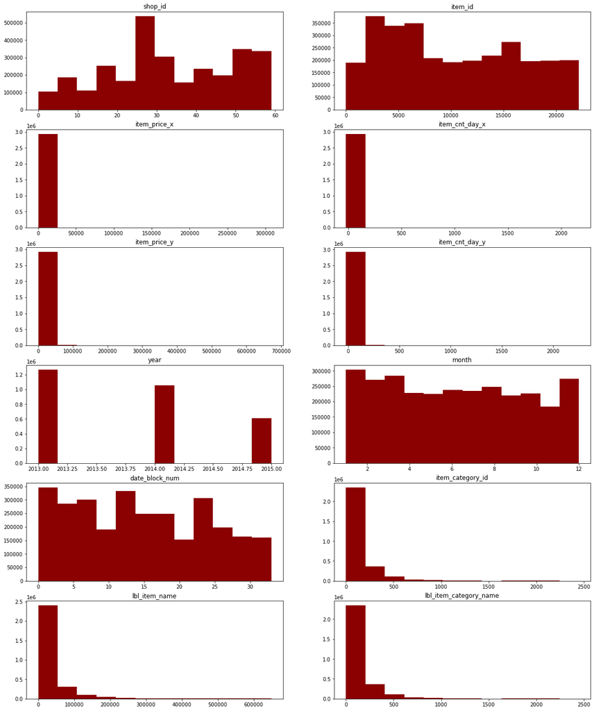

```python
%%time

# brand_new_train 데이터셋의 features

features = ['shop_id', 'item_id',
            'item_price_x', 'item_cnt_day_x',
            'item_price_y', 'item_cnt_day_y',
            'year', 'month',
            'date_block_num', 'item_category_id',
            'lbl_item_name', 'lbl_item_category_name']
i = 1

plt.figure(figsize=(20, 25))

for feature in features:
    plt.subplot(6, 2, i)     # 6행 2열
    plt.hist(brand_new_train[feature], bins=12, color='darkred')
    plt.title(feature)
    i += 1
```

## 나. seaborn

### ㄱ. 막대그래프 (barplot)

```python
import seaborn as sns
```

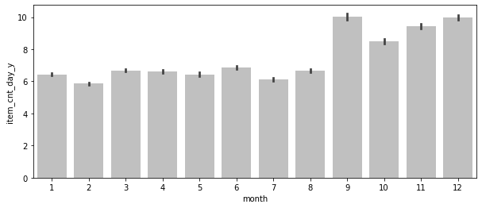

```
Wall time: 55.6 s
```

```python
%%time

# 월별 판매량.

plt.figure(figsize=(10, 4))

sns.barplot(x='month', y='item_cnt_day_y', color='silver', data=brand_new_train)

plt.show()
```

< 그래프 해석 >

- 1년 중, 9, 10, 11 12월에 판매량이 가장 많다.

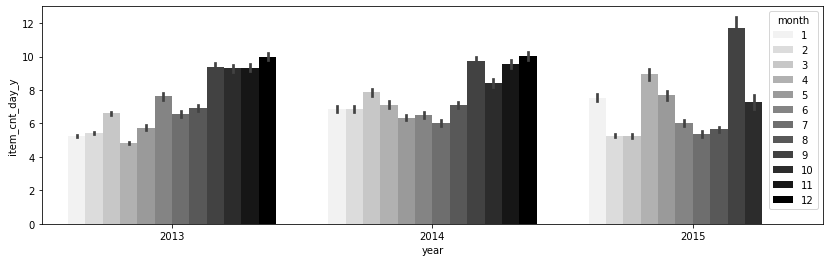

```
Wall time: 28 s
```

```python
%%time

# 각 연도별 월별 판매량.

plt.figure(figsize=(14, 4))

sns.barplot(x='year', y='item_cnt_day_y', hue='month', color='black', data=brand_new_train)

plt.show()
```

### ㄴ. 히트맵 (heatmap)

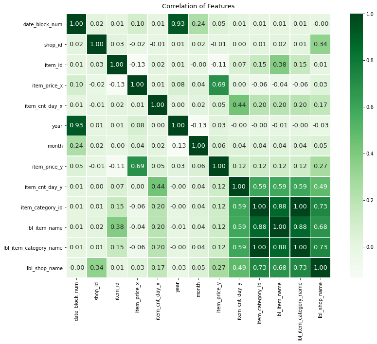

```
Wall time: 2.72 s
```

```python
%%time

plt.figure(figsize=(14,10))
plt.title("Correlation of Features", y=1.01, size=13)

sns.heatmap(data=brand_new_train.corr(), # 상관관계 표시.
            square=True,                 # 각 셀의 모양.
            linewidths=0.5,              # 각 셀의 선 두께.
            cmap="Greens",               # 각 셀의 색상.
            annot=True,                  # annotation(주석). 각 셀에 값 표시.
            fmt=".2f",                   # format : 소수 둘째자리까지 값 표시.
            annot_kws = {"size":13},     # 각 셀의 글자 크기.
            cbar=True)                   # 컬러바 표시.
plt.show()
```

< 그래프 해석 >

- target 값인 'item_cnt_day_y'는
  - 'item_category_id', 'lbl_item_name', 'lbl_item_category_name'와 가장 상관관계가 높고
  - 그 다음으로 'lbl_shop_name', 'item_cnt_day_x'와 높은 상관관계가 있다.

# 4. 머신러닝

## 가. train_test_split

```python
from sklearn.model_selection import train_test_split

sel_1 = ['shop_id', 'item_id', 'item_category_id', 'lbl_item_name', 'lbl_shop_name']
sel_2 = 'item_cnt_day_y'

X_train_all = brand_new_train[sel_1] # 트레인 입력
X_test_all = brand_new_test[sel_1]   # 테스트 입력
y_train_all = brand_new_train[sel_2] # 트레인 출력

X_train, X_test, y_train, y_test = train_test_split(X_train_all, y_train_all,
                                                    random_state=0)
```

## 나. 여러가지 머신러닝 모델

### ㄱ. k-최근접 이웃

```python
%%time

from sklearn.neighbors import KNeighborsRegressor

model = KNeighborsRegressor().fit(X_train, y_train)
print('훈련 세트 결정계수(0~1)   :', model.score(X_train, y_train))
print('테스트 세트 결정계수(0~1) :', model.score(X_test, y_test))
```

```
훈련 세트 결정계수(0~1)   : 0.8864490017440602
테스트 세트 결정계수(0~1) : 0.8598913400074426
Wall time: 49.2 s
```

#### 그리드 서치

```python
%%time

best_score = 0

for n_neighbors in [1, 3, 5, 7, 9, 11, 13, 15]:
    model = KNeighborsRegressor(n_neighbors=n_neighbors).fit(X_train, y_train)
    score = model.score(X_test, y_test)
    if score > best_score:
        best_score = score
        best_parameters = {'n_neighbors':n_neighbors}

print('테스트 세트 최고 결정계수(0~1) :', best_score)
print('최적의 매개변수                :', best_parameters)
```

```
테스트 세트 최고 결정계수(0~1) : 0.8677202432897002
최적의 매개변수                : {'n_neighbors': 11}
Wall time: 3min 9s
```

### ㄴ. 선형모델

- LinearRegression

```python
%%time

from sklearn.linear_model import LinearRegression

model = LinearRegression().fit(X_train, y_train)
print('훈련 세트 결정계수(0~1)   :', model.score(X_train, y_train))
print('테스트 세트 결정계수(0~1) :', model.score(X_test, y_test))
```

```
훈련 세트 결정계수(0~1)   : 0.39396117508743167
테스트 세트 결정계수(0~1) : 0.36561633948476624
Wall time: 2.19 s
```

- Lasso

```python
%%time

from sklearn.linear_model import Lasso

model = Lasso().fit(X_train, y_train)
print('훈련 세트 결정계수(0~1)   :', model.score(X_train, y_train))
print('테스트 세트 결정계수(0~1) :', model.score(X_test, y_test))
```

```
훈련 세트 결정계수(0~1)   : 0.3939547394904199
테스트 세트 결정계수(0~1) : 0.36561117302561963
Wall time: 2.99 s
```

```
* 그리드 서치
```

```python
%%time

best_score = 0

for alpha in [0.001, 0.001, 0.01, 0.1, 1, 10, 100, 1000]:
    model = Lasso(alpha=alpha).fit(X_train, y_train)
    score = model.score(X_test, y_test)
    if score > best_score:
        best_score = score
        best_parameters = {'alpha':alpha}

print('테스트 세트 최고 결정계수(0~1) :', best_score)
print('최적의 매개변수                :', best_parameters)
```

```
테스트 세트 최고 결정계수(0~1) : 0.365616346814697
최적의 매개변수                : {'alpha': 0.1}
Wall time: 26.9 s
```

- Ridge

```python
%%time

from sklearn.linear_model import Ridge

model = Ridge().fit(X_train, y_train)
print('훈련 세트 결정계수(0~1)   :', model.score(X_train, y_train))
print('테스트 세트 결정계수(0~1) :', model.score(X_test, y_test))
```

```
훈련 세트 결정계수(0~1)   : 0.3939611750874318
테스트 세트 결정계수(0~1) : 0.3656163394847639
Wall time: 435 ms
```

```
* 그리드 서치
```

```python
%%time

best_score = 0

for alpha in [0.001, 0.001, 0.01, 0.1, 1, 10, 100, 1000]:
    model = Ridge(alpha=alpha).fit(X_train, y_train)
    score = model.score(X_test, y_test)
    if score > best_score:
        best_score = score
        best_parameters = {'alpha':alpha}

print('테스트 세트 최고 결정계수(0~1) :', best_score)
print('최적의 매개변수                :', best_parameters)
```

```
테스트 세트 최고 결정계수(0~1) : 0.36561633948476624
최적의 매개변수                : {'alpha': 0.001}
Wall time: 2.07 s
```

### ㄷ. 결정트리

```python
%%time

from sklearn.tree import DecisionTreeRegressor

model = DecisionTreeRegressor().fit(X_train, y_train)
print('훈련 세트 결정계수(0~1)   :', model.score(X_train, y_train))
print('테스트 세트 결정계수(0~1) :', model.score(X_test, y_test))
```

```
훈련 세트 결정계수(0~1)   : 0.9050476910952697
테스트 세트 결정계수(0~1) : 0.8824661453709134
Wall time: 20.9 s
```

#### 그리드 서치

```python
%%time

best_score = 0

for max_depth in [1, 5, 10, 15, 20, 25, 30, 35, 40, 45, 50]:
    model = DecisionTreeRegressor(max_depth=max_depth).fit(X_train, y_train)
    score = model.score(X_test, y_test)
    if score > best_score:
        best_score = score
        best_parameters = {'max_depth':max_depth}

print('테스트 세트 최고 결정계수(0~1) :', best_score)
print('최적의 매개변수                :', best_parameters)
```

```
테스트 세트 최고 결정계수(0~1) : 0.8824663560092838
최적의 매개변수                : {'max_depth': 50}
Wall time: 2min 41s
```

### ㄹ. 결정트리의 앙상블

```python
### 시간이 너무 오래걸리고, 결정트리와 성능이 거의 비슷하다 판단하여 이하 생략.
```

- RandomForestRegressor

```python
'''
from sklearn.ensemble import RandomForestRegressor

model = RandomForestRegressor().fit(X_train, y_train)
print('훈련 세트 결정계수(0~1)   :', model.score(X_train, y_train))
print('테스트 세트 결정계수(0~1) :', model.score(X_test, y_test))
'''
```

```
"\nfrom sklearn.ensemble import RandomForestRegressor\n\nmodel = RandomForestRegressor().fit(X_train, y_train)\nprint('훈련 세트 결정계수(0~1)   :', model.score(X_train, y_train))\nprint('테스트 세트 결정계수(0~1) :', model.score(X_test, y_test))\n"
```

```
* 그리드 서치
```

```python
'''
best_score = 0

for n_estimators in [10, 100, 200]:
    model = RandomForestRegressor(n_estimators=n_estimators).fit(X_train, y_train)
    score = model.score(X_test, y_test)
    if score > best_score:
        best_score = score
        best_parameters = {'n_estimators':n_estimators}

print('테스트 세트 최고 결정계수(0~1) :', best_score)
print('최적의 매개변수                :', best_parameters)
'''
```

```
"\nbest_score = 0\n\nfor n_estimators in [10, 100, 200]:\n    model = RandomForestRegressor(n_estimators=n_estimators).fit(X_train, y_train)\n    score = model.score(X_test, y_test)\n    if score > best_score:\n        best_score = score\n        best_parameters = {'n_estimators':n_estimators}\n    …
```

- GradientBoostingRegressor

```python
'''
from sklearn.ensemble import GradientBoostingRegressor

model = GradientBoostingRegressor().fit(X_train, y_train)
print('훈련 세트 결정계수(0~1)   :', model.score(X_train, y_train))
print('테스트 세트 결정계수(0~1) :', model.score(X_test, y_test))
'''
```

```
"\nfrom sklearn.ensemble import GradientBoostingRegressor\n\nmodel = GradientBoostingRegressor().fit(X_train, y_train)\nprint('훈련 세트 결정계수(0~1)   :', model.score(X_train, y_train))\nprint('테스트 세트 결정계수(0~1) :', model.score(X_test, y_test))\n"
```

```
* 그리드 서치
```

```python
'''
best_score = 0

for n_estimators in [10, 100, 200]:
    model = RandomForestRegressor(n_estimators=n_estimators).fit(X_train, y_train)
    score = model.score(X_test, y_test)
    if score > best_score:
        best_score = score
        best_parameters = {'n_estimators':n_estimators}

print('테스트 세트 최고 결정계수(0~1) :', best_score)
print('최적의 매개변수                :', best_parameters)
'''
```

```
"\nbest_score = 0\n\nfor n_estimators in [10, 100, 200]:\n    model = RandomForestRegressor(n_estimators=n_estimators).fit(X_train, y_train)\n    score = model.score(X_test, y_test)\n    if score > best_score:\n        best_score = score\n        best_parameters = {'n_estimators':n_estimators}\n    …
```

# 5. 결론

## 가. 가장 성능이 좋은 모델 제출.

- 결정트리 > k-최근접 이웃 > 선형모델

### ㄱ. 결정트리

```python
model = DecisionTreeRegressor(max_depth=50).fit(X_train, y_train)

pred = model.predict(X_test_all)
pred
```

```
array([1., 1., 1., ..., 2., 1., 1.])
```

```python
sub['item_cnt_month'] = pred

sub
```

|  | ID | item_cnt_month |
| --- | --- | --- |
| 0 | 0 | 1.0 |
| 1 | 1 | 1.0 |
| 2 | 2 | 1.0 |
| 3 | 3 | 1.0 |
| 4 | 4 | 1.0 |
| ... | ... | ... |
| 214195 | 214195 | 1.0 |
| 214196 | 214196 | 1.0 |
| 214197 | 214197 | 2.0 |
| 214198 | 214198 | 1.0 |
| 214199 | 214199 | 1.0 |

214200 rows × 2 columns

```python
sub.to_csv("Final.csv", index=False)
```